# cDNA Pipette Exercise: Serial Dilutions

## Learning objectives

- Develop accurate and repeatable pipetting skills
- Prepare a serial dilution of nucleic acids with precision and accuracy
- Analyze and interpret a spectral data from a NanoDrop

# Rationale

The entirety of the molecular biology workflow consists of accurate and repeatable pipetting skills. Without the ability to pipette carefully and consistently, your data will be unusable. To foster and monitor pipetting skills, as well as to get you thinking of dilutions and working concentrations, we will begin with a simple pipetting exercise. This exercise will also introduce you to the use of the [NanoDrop](http://www.nanodrop.com) for quantifying nucleic acids via spectrophotometry.

## Serial dilutions

A serial dilution is the stepwise dilution of a substance in solution. Usually the dilution factor at each step is constant, resulting in descending concentration in logarithmic fashion. Serial dilutions are used to accurately create highly diluted solutions or to create standard curves with a logarithmic scale. Ten-fold and two-fold serial dilutions are commonly used in molecular biology.

A **ten-fold serial dilution** reduced the concentration by a factor of 10. For instance, the final concentration of the series could be: 100 M, 10 M, 1 M, 0.1 M, 0.01 M, and 0.001 M.

A **two-fold serial dilution** reduces the concentration by one half. For instance, the final concentration of the series could be: 200 M, 100 M, 50 M, 25 M, 12.5 M, 6.25 M. Here is an example of how one might create a two-fold dilution series.

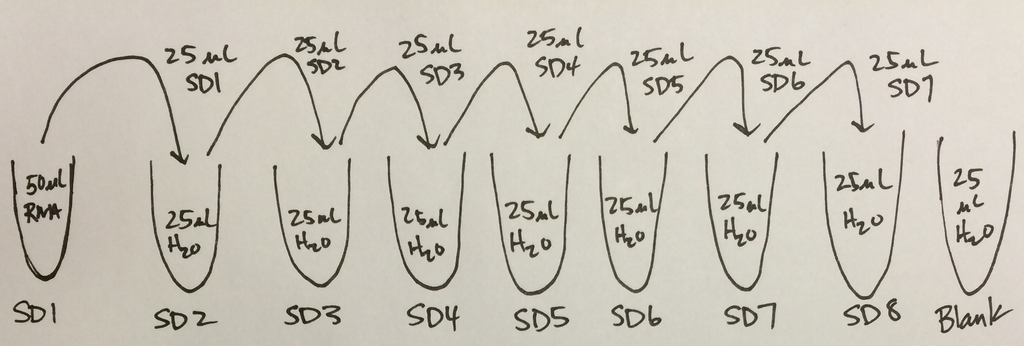

## EXERCISE ONE – PIPETTING EXERCISE AND USING THE NANODROP

1. Obtain an aliquot of RNA for use in the exercise. What is the initial listed concentration of the RNA? Record this number in your notebook.
2. Blank the NanoDrop with nuclease-free water. Before diluting your RNA, spec the RNA out on the NanoDrop machine. Record the concentration and the OD260/280 in your lab notebook. If possible, save the output of the NanoDrop and import it into your PowerPoint notebook file. What is this output, and what information does it give you about the RNA? What information is missing from this RNA measurement? How does the measured concentration compare with the reported concentration of the RNA standard?
3. Using the starting concentration you just measured on the NanoDrop, create a dilution series to test your pipetting skills and determine the detection limits of the NanoDrop. Design a dilution series that will cover at least 5 concentrations and will result in a final concentration < 0.5 ng/ul. Check with one of the instructors before beginning your dilution series to make sure it is well designed. (Hint: Make sure your final volumes are reasonable. You don’t need 100 mL if you are only going to use 2 uL.)
4. Quantify the concentration of RNA in your dilution series using the NanoDrop. Note any changes in the OD260/280 or the spectrum across your samples. Record in your notebook.
5. Plot the results of your dilution series with the dilution factor (or predicted concentration) on the X-axis and the measured RNA concentration on the Y-axis. Fit a line to the data. Include this figure in your PowerPoint notebook.
6. Interpret the results. What do the slope and y-intercept of this line represent?